# 11 Supervised learning with logistic regression

# Introduction to Logistic Regression

Logistic regression is one of the most widely used statistical methods for modeling the relationship between a binary response variable and one or more predictor variables. While regression models like linear regression predict a continuous outcome, logistic regression predicts the probability of an event occurring, specifically when the outcome is binary.

## Background

In many situations, we are interested in understanding how a binary response variable relates to one or more predictors. Examples include:

- Predicting whether an email is spam (1) or not (0).
- Determining whether a tumor is malignant (1) or benign (0).
- Assessing if a student will pass (1) or fail (0) an exam based on hours of study.

For such binary response variables, predicting the probability of an event occurring can provide more meaningful insights than simply classifying an observation into one of two categories.

# Prepare the workspace

```r
options(
  digits = 2,
  scipen = 999,
  warn = -1
)
rm(
  list = ls()
)
library(magrittr)
```

# Why Not Use Linear Regression for Binary Outcomes?

When dealing with a binary response variable, a natural question that arises is: Why can’t we use linear regression, as we do for continuous response variables? The answer lies in the nature of the output and the assumptions behind linear regression. Let’s delve into the reasons:

## Predicted Values Outside [0,1]

Linear regression predicts values that can fall outside the range [0,1]. When predicting probabilities, this is problematic. A predicted value less than 0 or greater than 1 does not make sense in the context of probability.

## Heteroscedasticity

Heteroscedasticity refers to the unequal scatter of residuals across levels of an independent variable. When modeling binary outcomes with linear regression, the residuals will not be distributed equally across the range of predicted values. This can result in unreliable and unstable estimates of coefficients.

## Non-linearity of Predicted Probabilities

The relationship between predictor variables and the probability of the outcome is not necessarily linear. While linear regression assumes a constant change in the response for a unit change in the predictor, this might not hold for probabilities, especially when they are close to 0 or 1. Logistic regression, on the other hand, accounts for this non-linearity by modeling the log-odds.

## Violation of Assumptions

Linear regression makes several assumptions:

- Linearity: There is a linear relationship between predictors and the outcome.
- Independence: Observations are independent of each other.
- Homoscedasticity: Equal variance of residuals.
- Normality: The residuals are normally distributed.

For binary outcomes, these assumptions are often violated, leading to biased or incorrect estimates.

While linear regression is powerful for modeling continuous outcomes, it’s not suitable for binary response variables. Using it can lead to nonsensical predictions, violations of key assumptions, and incorrect inferences. Logistic regression, with its ability to model the log-odds and produce probabilities bounded between 0 and 1, is a more appropriate choice for binary outcomes.

# Data Preparation for Logistic Regression

Logistic regression, like many statistical methods, requires data to be prepared and cleaned before model fitting. This ensures the results are meaningful, interpretable, and generalizable. Below are key steps and considerations in preparing your data for logistic regression:

```r
M_mushrooms <- readr::read_csv(
  file = "/Users/thienpham/Data Mining/Data/prepared_mushrooms.csv",
  col_types = "cnnnnnnnnnnnnnnnnnnnnnn"
) %>%
  dplyr::mutate(
    train_test = ifelse(runif(dplyr::n()) > 0.5,"Train","Test")
  ) %>%
  as.data.frame()
```

## Ensure Binary Outcome

Your response variable should be binary, meaning it has only two possible outcomes or levels. If you have a response variable with multiple categories, you would need to consider other techniques, like multinomial logistic regression, or you could convert it into a binary outcome, if appropriate.

## Handle Missing Data

### Logistic Regression and Missing Values

Logistic regression cannot handle missing values. If you attempt to fit a logistic regression model with missing data, R will omit all records with one or more missing values. Therefore, it’s imperative to address missing data before model fitting.

### Strategies to Address Missing Data

1. **Omission**: One of the simplest methods is to omit observations with missing values. This is often referred to as listwise deletion. While it’s straightforward, the downside is the potential loss of valuable data, especially if many observations have missing values.
2. **Imputation**: Instead of deleting missing values, you can estimate and fill them based on the information available. Common methods include:
   - **Mean/Median Imputation**: Fill missing values with the mean or median of the observed values.
   - **K-Nearest Neighbors**: Fill missing values based on similar observations.
   - **Regression Imputation**: Use a regression model to predict and fill missing values.

## Check for Outliers

Though logistic regression is more robust than linear regression against non-normality, outliers can still influence the estimates of the coefficients. Visual tools like boxplots or scatter plots can be useful in detecting outliers.

## Feature Scaling (Optional)

While logistic regression is not sensitive to different scales among predictors, if you plan on using regularization (like in ridge or lasso regression), it’s important to standardize or normalize the features. With standard logistic regression and linear regression, feature scaling will not improve model performance, but may improve interpretibility.

## Encoding Categorical Predictors

If your dataset contains categorical predictor variables, they need to be converted into a format suitable for modeling. This often means converting them into dummy or indicator variables. R’s `glm` function handles factors elegantly by introducing dummy variables internally, but it’s good to be aware of the process.

Data preparation is a critical step before fitting a logistic regression model. Properly prepared data ensures the integrity and reliability of the model’s results. By ensuring a binary outcome, handling missing data, checking for outliers, and appropriately encoding categorical predictors, you lay a strong foundation for accurate and insightful logistic regression analysis.

# Model Fitting in Logistic Regression

After data preparation, the next critical step in logistic regression analysis is model fitting. This step involves determining the best-fitting logistic curve to the observed data. The underlying process and concepts behind this fitting can seem intricate, but they are fundamental to understanding the mechanics of logistic regression.

## Maximum Likelihood Estimation (MLE)

Logistic regression uses the method of Maximum Likelihood Estimation (MLE) to determine the coefficients that define the logistic curve. In essence, MLE tries to find the values of the coefficients that maximize the likelihood of the observed data given the model.

### Likelihood vs. Probability

It’s important to distinguish between likelihood and probability. While they are related concepts:

- **Probability**: Refers to the chance of observing data given a set of parameters (like coefficients). It’s a measure before observing the data.
- **Likelihood**: Refers to how well the model explains the observed data. Given the data, what’s the likelihood that a particular set of parameters produced it?

### How MLE Works

In logistic regression, the goal of MLE is to adjust the coefficients ($\beta$’s) to find the logistic curve that best fits the data. “Best fit” means that, if you were to compute the likelihood of the observed data for this logistic curve, it would be the highest possible.

Mathematically, the likelihood $L(\beta)$ is defined as:

$$L(\beta) = \prod_{i=1}^{n} p(x_i)^{y_i}
(1 - p(x_i))^{(1 - y_i)}$$

Where: - $y_i$ is the observed response for the ith observation. - $p(x_i)$ is the probability of the event given the predictors for the ith observation, as defined by the logistic function.

MLE aims to maximize $L(\beta)$.

## Estimating the Conditional Expected Value

Once we’ve used MLE to estimate the coefficients, the logistic regression model can be used to estimate the conditional expected value of the response variable given some predictors. This is essentially predicting the probability of an event given the values of the predictor variables.

For instance, in the equation:

$$P(Y=1|X) = \frac{e^{\beta_0 +
\beta_1X_1 + ... + \beta_pX_p}}{1 + e^{\beta_0 + \beta_1X_1 + ... +
\beta_pX_p}}$$

The term $P(Y=1|X)$ represents the conditional expected value or the probability of $Y$ being 1 given the predictors $X$.

## Fitting a Model in R

In R, we can fit a logistic regression model using the `glm` function, specifying the `family` argument as “binomial”.

```r
glm_logit <- glm(
  formula = target ~ bruises + odor + gill_color + population,
  data = M_mushrooms %>%
    dplyr::select(-class,-train_test),
  family = binomial(link = "logit")
)
glm_logit
```

```
##
## Call:  glm(formula = target ~ bruises + odor + gill_color + population,
##     family = binomial(link = "logit"), data = M_mushrooms %>%
##         dplyr::select(-class, -train_test))
##
## Coefficients:
## (Intercept)      bruises         odor   gill_color   population
##     -23.715        0.707       25.118        0.714        3.101
##
## Degrees of Freedom: 8123 Total (i.e. Null);  8119 Residual
## Null Deviance:       11300
## Residual Deviance: 903   AIC: 913
```

A positive coefficient means, increasing that predictor variable will increase the likelihood of seeing a 1 in our response variable.

```r
coef(
  object = glm_logit
)
```

```
## (Intercept)     bruises        odor  gill_color  population
##      -23.72        0.71       25.12        0.71        3.10
```

```r
summary(
  object = glm_logit
)
```

```
##
## Call:
## glm(formula = target ~ bruises + odor + gill_color + population,
##     family = binomial(link = "logit"), data = M_mushrooms %>%
##         dplyr::select(-class, -train_test))
##
## Coefficients:
##             Estimate Std. Error z value             Pr(>|z|)
## (Intercept)  -23.715    419.360   -0.06              0.95490
## bruises        0.707      0.212    3.34              0.00085 ***
## odor          25.118    419.360    0.06              0.95224
## gill_color     0.714      0.198    3.60              0.00032 ***
## population     3.101      0.285   10.87 < 0.0000000000000002 ***
## ---
## Signif. codes:  0 '***' 0.001 '**' 0.01 '*' 0.05 '.' 0.1 ' ' 1
##
## (Dispersion parameter for binomial family taken to be 1)
##
##     Null deviance: 11251.76  on 8123  degrees of freedom
## Residual deviance:   902.52  on 8119  degrees of freedom
## AIC: 912.5
##
## Number of Fisher Scoring iterations: 20
```

We see that the number of iteration it takes for our model to converge is 20. The higher the number relative to complexity of type of model, then thats a good sign thats a bad model structure, the data and model do not match up well. If it takes a simple model like linear or logistic regression a lot of iterations to converge then its not the right model to use.

```r
anova(
  object = glm_logit
)
```

```
## Analysis of Deviance Table
##
## Model: binomial, link: logit
##
## Response: target
##
## Terms added sequentially (first to last)
##
##
##            Df Deviance Resid. Df Resid. Dev
## NULL                        8123      11252
## bruises     1     2167      8122       9085
## odor        1     7988      8121       1097
## gill_color  1        5      8120       1092
## population  1      190      8119        903
```

Unlike with linear regression (sum of squares error) we use deviance to interpret maximum likelihood.

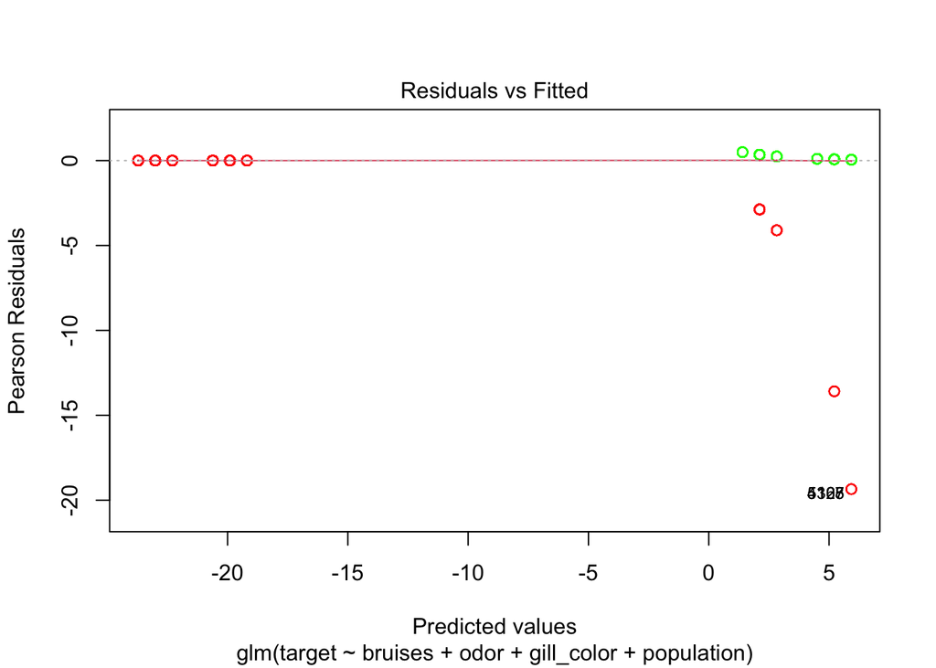

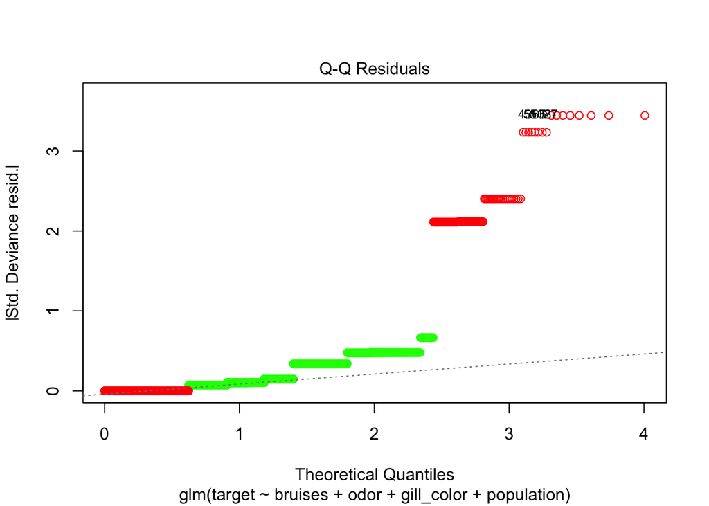

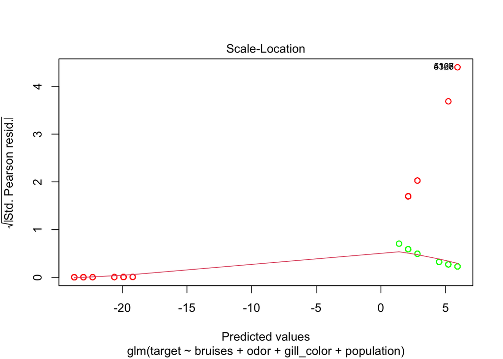

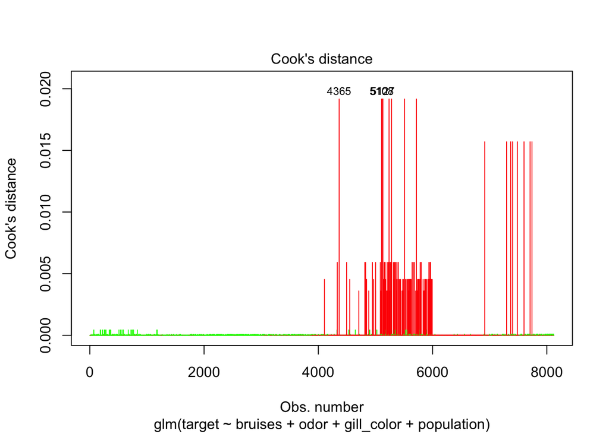

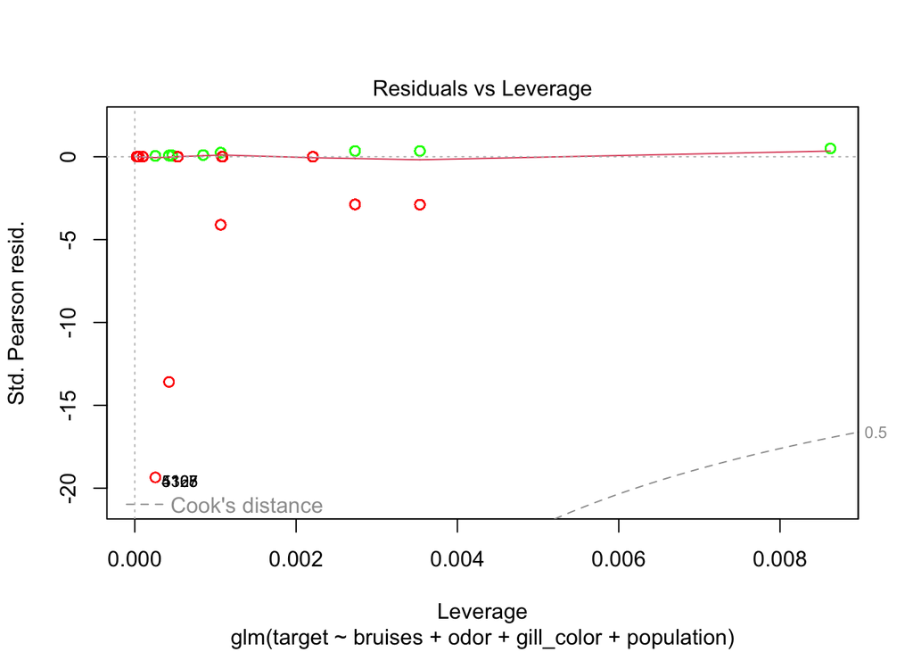

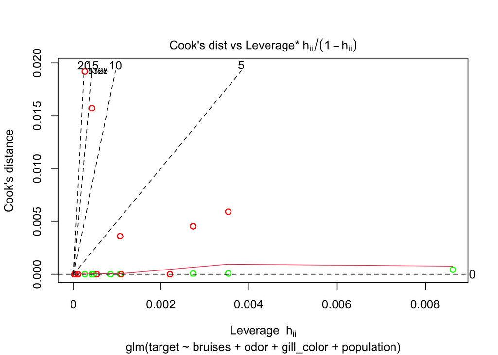

```r
M_mushrooms$color <- ifelse(
  test = M_mushrooms$target > 0.5,
  yes = "green",
  no = "red"
)
plot(
  x = glm_logit,
  which = 1:6,
  col = M_mushrooms$color
)
```

The output provides the estimated coefficients, their standard errors, the z-values, and the associated p-values. It’s these coefficients that MLE has determined to be the most likely given the data.

Model fitting is a central aspect of logistic regression, and understanding the underlying mechanics, particularly the role of Maximum Likelihood Estimation, is crucial. Once fitted, the model can be used to estimate the conditional expected values, allowing us to predict the probability of outcomes based on new data.

# Estimating Coefficients in Logistic Regression

In logistic regression, coefficients are central to understanding the relationship between predictor variables and the response. These coefficients, often denoted by $\beta$’s, quantify the change in the log-odds of the response for a unit change in the predictor. This section delves into how these coefficients are estimated and their interpretation.

## The Log-Odds and the Logistic Function

Before diving into coefficient estimation, it’s essential to grasp the concept of log-odds. For a binary outcome where $P(Y=1)$ is the probability of the event occurring:

$$\text{logit}(P(Y=1)) = \log \left(
\frac{P(Y=1)}{1-P(Y=1)} \right)$$

The logistic regression model relates the log-odds of the response and predictors:

$$\log \left( \frac{P(Y=1)}{1-P(Y=1)}
\right) = \beta_0 + \beta_1X_1 + ... + \beta_pX_p$$

## Estimation Using Maximum Likelihood

As mentioned in the model fitting section, logistic regression employs Maximum Likelihood Estimation (MLE) to estimate coefficients. MLE identifies the set of coefficients that maximize the likelihood of observing the given data.

In more technical terms, for a set of observations $y_1, y_2, ... y_n$ and predictors $x_1, x_2, ... x_n$, MLE finds:

$$\hat{\beta_0}, \hat{\beta_1}, ...
\hat{\beta_p}$$

That maximize:

$$L(\beta_0, \beta_1, ... \beta_p) =
\prod_{i=1}^{n} P(Y=y_i|X=x_i)$$

## Interpreting the Coefficients

Understanding and interpreting the coefficients is crucial. Here’s a guideline for interpretation:

- **Intercept ($\beta_0$)**: The log-odds of the response when all predictors are 0. In many practical situations, it might not have a clear interpretation, especially if 0 is not a meaningful value for the predictors.
- **For Continuous Predictors**: A one-unit increase in the predictor results in a change of $\beta$ in the log-odds of the response, holding all other predictors constant. If you exponentiate $\beta$, you get the odds ratio associated with a one-unit increase in the predictor.
- **For Categorical Predictors**: The coefficient represents the difference in the log-odds between the reference category (omitted category) and the respective level of the categorical predictor.

### Example:

If a predictor $X$ has a coefficient $\beta = 2$, then:

- A one-unit increase in $X$ is associated with an increase of 2 in the log-odds of the response.
- The odds of the response occurring (as opposed to not occurring) are $e^2$ times higher for a one-unit increase in $X$, holding all else constant.

## Estimating Coefficients in R

Using the `glm` function in R with the `family="binomial"` argument will yield the estimated coefficients:

```r
glm_logit <- glm(
  formula = target ~ bruises + odor + gill_color + population,
  data = M_mushrooms %>%
    dplyr::select(-class,-train_test),
  family = binomial(link = "logit")
)
glm_logit
```

```
##
## Call:  glm(formula = target ~ bruises + odor + gill_color + population,
##     family = binomial(link = "logit"), data = M_mushrooms %>%
##         dplyr::select(-class, -train_test))
##
## Coefficients:
## (Intercept)      bruises         odor   gill_color   population
##     -23.715        0.707       25.118        0.714        3.101
##
## Degrees of Freedom: 8123 Total (i.e. Null);  8119 Residual
## Null Deviance:       11300
## Residual Deviance: 903   AIC: 913
```

```r
coef(
  object = glm_logit
)
```

```
## (Intercept)     bruises        odor  gill_color  population
##      -23.72        0.71       25.12        0.71        3.10
```

The output gives the estimated coefficients for the intercept and the predictor(s).

Coefficients play a pivotal role in understanding the logistic regression model. They provide a quantitative measure of the relationship between the predictors and the log-odds of the response. Properly estimating and interpreting these coefficients is key to making insightful inferences and predictions from logistic regression analysis.

# Link Functions in Logistic Regression

In generalized linear models (GLMs), the link function describes the relationship between the linear predictor and the mean of the response variable. In logistic regression, a special case of GLM, the link function connects the predictors and the probability of the response. While the logit link is most commonly associated with logistic regression, several other link functions exist, each with its own characteristics and applications.

## Logit Link

### **When to Use:**

Most commonly used for binary logistic regression. Very flexible, probably link function one you want to use.

### **Formula:**

$$g(p) = \log \left( \frac{p}{1-p}
\right)$$

### **Interpretation:**

For a one-unit increase in the predictor $X$, the change in the log-odds of the response is $\beta$. The odds ratio for a one-unit increase in $X$ is $e^{\beta}$, keeping other variables constant.

```r
glm_logit <- glm(
  formula = target ~ bruises + odor + gill_color + population,
  data = M_mushrooms %>%
    dplyr::select(-class,-train_test),
  family = binomial(link = "logit")
)
glm_logit
```

```
##
## Call:  glm(formula = target ~ bruises + odor + gill_color + population,
##     family = binomial(link = "logit"), data = M_mushrooms %>%
##         dplyr::select(-class, -train_test))
##
## Coefficients:
## (Intercept)      bruises         odor   gill_color   population
##     -23.715        0.707       25.118        0.714        3.101
##
## Degrees of Freedom: 8123 Total (i.e. Null);  8119 Residual
## Null Deviance:       11300
## Residual Deviance: 903   AIC: 913
```

## Probit Link

### **When to Use:**

When errors are assumed to follow a standard normal distribution. Common in some areas of social sciences and toxicology.

### **Formula:**

$$g(p) = \Phi^{-1}(p)$$
Where $\Phi^{-1}$ is the quantile function (inverse of the CDF) of the standard normal distribution.

### **Interpretation:**

The coefficients in a probit model represent the change in the number of standard deviations from the mean of the response variable’s underlying latent variable for a one-unit change in the predictor.

```r
glm_probit <- glm(
  formula = target ~ bruises + odor + gill_color + population,
  data = M_mushrooms %>%
    dplyr::select(-class,-train_test),
  family = binomial(link = "probit")
)
glm_probit
```

```
##
## Call:  glm(formula = target ~ bruises + odor + gill_color + population,
##     family = binomial(link = "probit"), data = M_mushrooms %>%
##         dplyr::select(-class, -train_test))
##
## Coefficients:
## (Intercept)      bruises         odor   gill_color   population
##      -7.511        0.303        8.497        0.264        1.259
##
## Degrees of Freedom: 8123 Total (i.e. Null);  8119 Residual
## Null Deviance:       11300
## Residual Deviance: 908   AIC: 918
```

## Cauchit (or Cauchy) Link

### **When to Use:**

Less common but can be useful if there’s a belief that the errors follow a Cauchy distribution, which has heavier tails than the normal distribution.

### **Formula:**

$$g(p) = \tan(\pi(p - 0.5))$$

### **Interpretation:**

Coefficients represent the change in the location parameter of the Cauchy distribution for a one-unit change in the predictor.

```r
glm_cauchit <- glm(
  formula = target ~ bruises + odor + gill_color + population,
  data = M_mushrooms %>%
    dplyr::select(-class,-train_test),
  family = binomial(link = "cauchit"),
  control = list(
    maxit = 1e5
  )
)
# good example of overfit coefficients
glm_cauchit
```

```
##
## Call:  glm(formula = target ~ bruises + odor + gill_color + population,
##     family = binomial(link = "cauchit"), data = M_mushrooms %>%
##         dplyr::select(-class, -train_test), control = list(maxit = 100000))
##
## Coefficients:
##   (Intercept)        bruises           odor     gill_color     population
## -94961238.986          0.703   94961240.566          3.008         57.381
##
## Degrees of Freedom: 8123 Total (i.e. Null);  8119 Residual
## Null Deviance:       11300
## Residual Deviance: 901   AIC: 911
```

## Log Link

### **When to Use:**

For count and proportion data in models like Poisson or binomial regression when a multiplicative model is appropriate.

### **Formula:**

$$g(p) = \log(p)$$

### **Interpretation:**

The expected value of the response changes by a multiplicative factor of $e^{\beta}$ for a one-unit increase in the predictor, holding other predictors constant.

## Cloglog (Complementary Log-log) Link

### **When to Use:**

Useful for modeling data where the probability of the event is extremely low or high. Common in survival analysis.

### **Formula:**

$$g(p) = \log(-\log(1 - p))$$

### **Interpretation:**

The coefficients represent the change in the log(-log) scale of the survival function for a one-unit change in the predictor.

Choosing the appropriate link function is paramount in logistic regression and other GLMs. While the logit link is widely used, understanding alternative link functions can be beneficial when modeling different types of data or when certain assumptions about the distribution of errors are in place. As always, interpretation of coefficients varies with the link function, so being cautious and understanding the context is vital for drawing meaningful insights.

```r
glm_cloglog <- glm(
  formula = target ~ bruises + odor + gill_color + population,
  data = M_mushrooms %>%
    dplyr::select(-class,-train_test),
  family = binomial(link = "cloglog"),
  control = list(
    maxit = 1e5
  )
)
glm_cloglog
```

```
##
## Call:  glm(formula = target ~ bruises + odor + gill_color + population,
##     family = binomial(link = "cloglog"), data = M_mushrooms %>%
##         dplyr::select(-class, -train_test), control = list(maxit = 100000))
##
## Coefficients:
## (Intercept)      bruises         odor   gill_color   population
##     -21.791        0.180       22.489        0.129        0.779
##
## Degrees of Freedom: 8123 Total (i.e. Null);  8119 Residual
## Null Deviance:       11300
## Residual Deviance: 913   AIC: 923
```

# Delving Deeper into the Logit Link in Logistic Regression

## The Logit Link and the Logistic Function

The logit link, as we previously discussed, is given by:

$$g(p) = \log \left( \frac{p}{1-p}
\right)$$

The inverse of this, the logistic function, maps any real-valued number to a value between 0 and 1, which can be interpreted as a probability:

$$P(Y=1) = \frac{e^{\beta_0 + \beta_1X_1
+ \beta_2X_2 + ... + \beta_pX_p}}{1 + e^{\beta_0 + \beta_1X_1 +
\beta_2X_2 + ... + \beta_pX_p}}$$

The logistic function ensures that our estimated probabilities are between 0 and 1, a necessity when modeling probability.

## Flexibility of the Logit Link

The logistic function’s S-shaped curve (sigmoid curve) is symmetric around 0.5. Its flexibility stems from its capacity to handle non-linearity between the predictors and the response’s probability. This allows it to approximate a variety of relationships relatively well.

Even if there’s a slight mis-specification in terms of the true underlying relationship between predictors and response, the logistic function provides a decent approximation, making it a robust choice in many scenarios.

## Odds and the Odds Ratio

Odds are another way to express probabilities. If $P(Y=1)$ is the probability of an event happening, the odds are given by:

$$\text{odds} = \frac{P(Y=1)}{1-P(Y=1)}$$

For logistic regression with the logit link:

$$\log \left( \frac{P(Y=1)}{1-P(Y=1)}
\right) = \beta_0 + \beta_1X_1 + ... + \beta_pX_p$$

The odds ratio for a predictor, say $X_1$, measures the factor by which the odds change for a one-unit increase in $X_1$. If $\beta_1$ is the coefficient for $X_1$, the odds ratio for $X_1$ is $e^{\beta_1}$.

### Interpretation:

- If $e^{\beta_1} = 1$: No change in odds with a one-unit increase in $X_1$.
- If $e^{\beta_1} > 1$: The odds increase (the event becomes more likely) with a one-unit increase in $X_1$.
- If $0 < e^{\beta_1} < 1$: The odds decrease (the event becomes less likely) with a one-unit increase in $X_1$.

The logit link’s enduring popularity in logistic regression can be attributed to its inherent flexibility and robustness in modeling various relationships. Understanding the nuances of the logistic function, odds, and odds ratios is crucial for interpreting results and making informed decisions based on logistic regression analyses.

# Implementing Logistic Regression in R

In R, implementing logistic regression is straightforward thanks to the comprehensive `glm` function (generalized linear model) in the base package. This section will guide you through the process, from loading the data to interpreting the model output.

## Making Predictions

You can make predictions using the `predict()` function. By default, it gives predictions on the log-odds scale. To obtain probabilities, use the `type` argument set to “response”.

```r
predict(
  object = glm_logit,
  newdata = unique(M_mushrooms)[1:5,],
  type = "link" # default type
)
```

```
##     1     2     3     4     5
## -19.2   5.9   5.9 -19.2   5.2
```

```r
predict(
  object = glm_logit,
  newdata = unique(M_mushrooms)[1:5,],
  type = "response"
)
```

```
##            1            2            3            4            5
## 0.0000000046 0.9973360554 0.9973360554 0.0000000046 0.9946119578
```

```r
predict(
  object = glm_logit,
  newdata = unique(M_mushrooms)[1:5,],
  type = "terms"
)
```

```
##   bruises odor gill_color population
## 1    0.41  -13       0.42        1.5
## 2    0.41   12       0.42        1.5
## 3    0.41   12       0.42        1.5
## 4    0.41  -13       0.42        1.5
## 5   -0.29   12       0.42        1.5
## attr(,"constant")
## [1] -8.2
```

## Model Validation

It’s crucial to validate your logistic regression model, e.g., by using a confusion matrix or ROC curve. The `caret` package offers excellent tools for this purpose.

```r
caret::confusionMatrix(
  data = factor(
    x = round(
      x = predict(
    object = glm_logit,
    newdata = M_mushrooms %>%
      dplyr::filter(train_test == "Test"),
    type = "response"
  ) > 0.5
    )
  ),
  reference = factor(
    x = M_mushrooms %>%
      dplyr::filter(train_test == "Test") %>%
      dplyr::pull(target)
  )
)
```

```
## Confusion Matrix and Statistics
##
##           Reference
## Prediction    0    1
##          0 1875    0
##          1   63 2106
##
##                Accuracy : 0.984
##                  95% CI : (0.98, 0.988)
##     No Information Rate : 0.521
##     P-Value [Acc > NIR] : < 0.0000000000000002
##
##                   Kappa : 0.969
##
##  Mcnemar's Test P-Value : 0.00000000000000566
##
##             Sensitivity : 0.967
##             Specificity : 1.000
##          Pos Pred Value : 1.000
##          Neg Pred Value : 0.971
##              Prevalence : 0.479
##          Detection Rate : 0.464
##    Detection Prevalence : 0.464
##       Balanced Accuracy : 0.984
##
##        'Positive' Class : 0
##
```

R provides a seamless and straightforward approach for fitting and interpreting logistic regression models. While the steps covered here offer a basic introduction, R’s ecosystem, replete with packages and tools, allows for extensive model evaluation, diagnostics, and advanced regression techniques.

# Understanding Variable Importance in Logistic Regression

In many modeling contexts, not only do we want to predict outcomes, but we also want to understand which variables are most influential in predicting these outcomes. This understanding can lead to better decision-making, improved model interpretability, and the ability to derive actionable insights from your data.

## Coefficient Magnitude

For a logistic regression model that uses the logit link, the magnitude of the coefficients can sometimes be used as an initial indicator of variable importance. The larger the absolute value of the coefficient, the larger its influence on the response variable, all else being equal. Absolute value of the z statistic is another way.

**However, a few caveats apply:** - Variables measured on larger scales can have smaller coefficients but still have a significant impact on the response. - Variables should be standardized (mean=0, variance=1) before interpreting coefficient magnitude as importance. Standardization allows for comparison on the same scale.

```r
coef(
  object = glm_logit
)
```

```
## (Intercept)     bruises        odor  gill_color  population
##      -23.72        0.71       25.12        0.71        3.10
```

## Wald Test

The Wald Test, which is part of the model output, compares the fit of the model with and without the variable. A significant Wald statistic indicates that the predictor is making a significant contribution to the model.

```r
summary(
  object = glm_logit
)
```

```
##
## Call:
## glm(formula = target ~ bruises + odor + gill_color + population,
##     family = binomial(link = "logit"), data = M_mushrooms %>%
##         dplyr::select(-class, -train_test))
##
## Coefficients:
##             Estimate Std. Error z value             Pr(>|z|)
## (Intercept)  -23.715    419.360   -0.06              0.95490
## bruises        0.707      0.212    3.34              0.00085 ***
## odor          25.118    419.360    0.06              0.95224
## gill_color     0.714      0.198    3.60              0.00032 ***
## population     3.101      0.285   10.87 < 0.0000000000000002 ***
## ---
## Signif. codes:  0 '***' 0.001 '**' 0.01 '*' 0.05 '.' 0.1 ' ' 1
##
## (Dispersion parameter for binomial family taken to be 1)
##
##     Null deviance: 11251.76  on 8123  degrees of freedom
## Residual deviance:   902.52  on 8119  degrees of freedom
## AIC: 912.5
##
## Number of Fisher Scoring iterations: 20
```

## Odds Ratio

In the context of logistic regression, the odds ratio can be a very insightful measure for variable importance. It indicates the change in odds resulting from a one-unit change in the predictor. An odds ratio of 1 suggests no change in odds due to the predictor, while a value greater (or less) than 1 indicates an increase (or decrease) in odds.

## Variable Importance from Bootstrapping

Bootstrapping is a resampling technique where we repeatedly and randomly sample observations with replacement from the dataset and fit the model. By examining how the coefficients vary across bootstrap samples, we can get an idea of their stability and importance.

## Drop-One Variable Importance

A straightforward approach is to drop one variable at a time, fit the model, and compare its performance with the full model. If dropping a variable results in a substantially worse fit, that variable can be considered important.

## Tools and Packages in R

The `caret` package in R offers a function called `varImp()` which calculates variable importance for a variety of model types, including logistic regression. It utilizes a collection of methods, for logistic regression the variable importance is the absolute value of the t-statistic for each model parameter. Other model structures have different methods of computing variable importance.

```r
caret::varImp(
  object = glm_logit
)
```

```
##            Overall
## bruises       3.34
## odor          0.06
## gill_color    3.60
## population   10.87
```

Variable importance is a crucial aspect of model interpretation, especially in fields like medicine, finance, or any domain where understanding the driving factors behind a prediction is as vital as the prediction itself. Several methods exist for logistic regression, and a combination of them can provide a more comprehensive perspective on variable significance.

## **ROC Curve and AUC**

The Receiver Operating Characteristic (ROC) curve plots the True Positive Rate (Sensitivity) against the False Positive Rate (1-Specificity) for various threshold values. The Area Under the Curve (AUC) provides an aggregate measure of model performance across all classification thresholds.

```r
roc_logit <- pROC::roc(
  response = M_mushrooms %>%
      dplyr::filter(train_test == "Test") %>%
      dplyr::pull(target),
  predictor = predict(
    object = glm_logit,
    newdata = M_mushrooms %>%
      dplyr::filter(train_test == "Test"),
    type = "response"
  )
)
pROC::auc(
  roc = roc_logit
)
```

```
## Area under the curve: 0.99
```

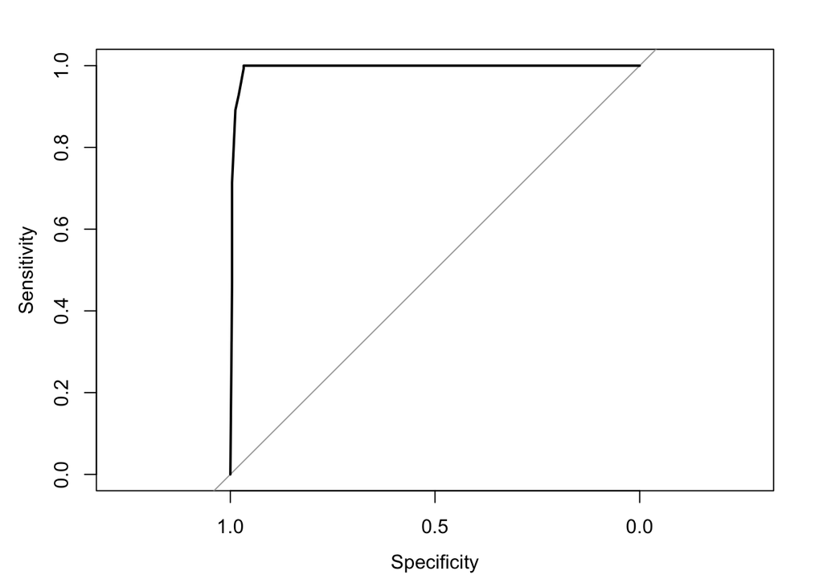

```r
plot(
  x = roc_logit
)
```

## **Log-Likelihood and AIC**

The log-likelihood is a measure of model fit. The Akaike Information Criterion (AIC) is derived from the log-likelihood and penalizes for the number of predictors, helping in model selection.

```r
logLik(
  object = glm_logit
)
```

```
## 'log Lik.' -451 (df=5)
```

```r
AIC(
  object = glm_logit
)
```

```
## [1] 913
```

## **Residuals Analysis**

Examining residuals can give insights into the model fit. In logistic regression, the deviance residuals are often used.

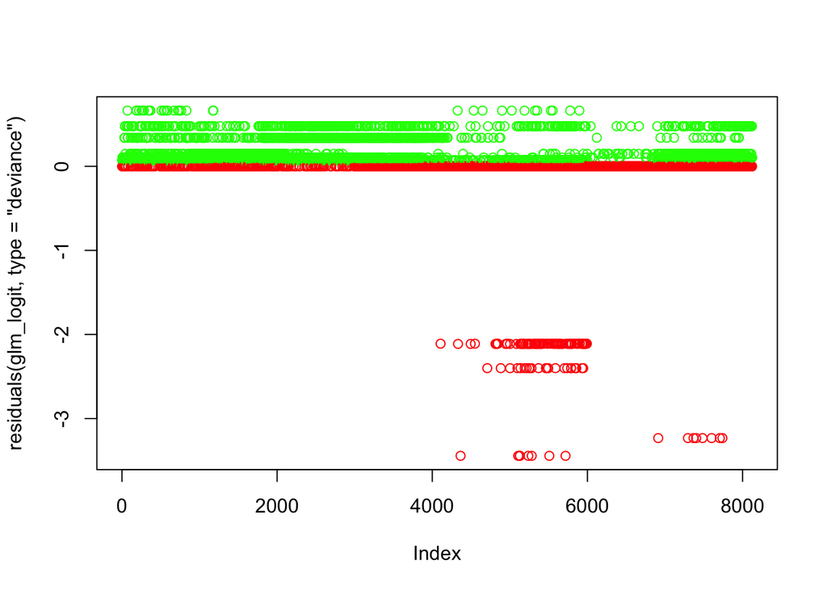

```r
plot(residuals(glm_logit, type="deviance"),col = M_mushrooms$color)
```

## **Cross-Validation**

Cross-validation involves dividing your data into subsets, training on some and testing on others. This provides a more robust estimate of model performance.

## **Bootstrap Resampling**

Bootstrapping can be used to assess the variability of model performance by repeatedly and randomly resampling observations.

Evaluating a logistic regression model involves a comprehensive look at various metrics and plots. R provides numerous tools and functions that make this process efficient and insightful. Always remember that while a model may have good metrics on the training data, the ultimate test of its efficacy is its performance on unseen data.

# Extending Logistic Regression to Multinomial Logistic Regression

When the outcome variable has more than two categories, the standard logistic regression is not suitable. For such cases, we use Multinomial Logistic Regression. It’s an extension of logistic regression where the response variable can have more than two possible discrete outcomes.

## Theory

For $K$ possible outcomes, the multinomial logistic model is:

$$\log \left( \frac{P(Y=k | X)}{P(Y=K |
X)} \right) = \beta_{k0} + \beta_{k1} X_1 + \beta_{k2} X_2 + \dots +
\beta_{kp} X_p$$

for $k = 1, 2, \dots, K-1$.

Here, $P(Y=K | X)$ is the “base category” against which we compare the odds of the other outcomes.

## Example using R

Let’s consider the `iris` dataset in R. The species variable has three categories: setosa, versicolor, and virginica. We can use multinomial logistic regression to predict species based on the four continuous predictors: Sepal.Length, Sepal.Width, Petal.Length, and Petal.Width.

```r
# Load necessary libraries
#library(nnet)

# Fit the model
multinom_model <- nnet::multinom(Species ~ Sepal.Length + Sepal.Width + Petal.Length + Petal.Width, data=iris)
# Summarize the model
summary(multinom_model)
```

```
## Call:
## nnet::multinom(formula = Species ~ Sepal.Length + Sepal.Width +
##     Petal.Length + Petal.Width, data = iris)
##
## Coefficients:
##            (Intercept) Sepal.Length Sepal.Width Petal.Length Petal.Width
## versicolor          19         -5.5        -8.7           14        -3.1
## virginica          -24         -7.9       -15.4           24        15.1
##
## Std. Errors:
##            (Intercept) Sepal.Length Sepal.Width Petal.Length Petal.Width
## versicolor          35           90         157           60          45
## virginica           36           90         157           60          46
##
## Residual Deviance: 12
## AIC: 32
```

```r
# Predictions
predicted_species <- predict(multinom_model, newdata=iris)
table(predicted_species, iris$Species)
```

```
##
## predicted_species setosa versicolor virginica
##        setosa         50          0         0
##        versicolor      0         49         1
##        virginica       0          1        49
```

## Limitations and Considerations

- **Collinearity**: Just as in binary logistic regression, multicollinearity can be a concern. Ensure predictor variables are not highly correlated.
- **Sample Size**: Each outcome group should have a reasonable sample size. Sparse groups might lead to unstable estimates.
- **Assumption of Independence**: Assumes that the log odds of the outcomes are independent.

Multinomial logistic regression is a versatile tool when dealing with categorical outcomes with more than two levels. It extends the binary logistic regression model to accommodate multiple categories, providing a broader scope for classification tasks in various fields.

# Conclusion

Logistic regression, both binary and multinomial, remains a staple in the world of statistical modeling and machine learning. Its flexibility, interpretability, and applicability to various real-world situations make it an invaluable tool for any data analyst, statistician, or machine learning practitioner. Through this lecture, you’ve garnered a deep understanding of its foundational concepts, the importance of data preparation, various methods for evaluating the model, and its extension to handle multiple classes. Now, it’s time to put this knowledge into practice.

# Homework Problems

1. **Binary Outcome Modeling**:
   - Find a dataset with a binary outcome. This could be from your own research, an open dataset online, or from a field of interest.
   - Perform a logistic regression analysis. Ensure you handle any missing data, standardize variables (if necessary), and interpret the model coefficients. What are the significant predictors for your outcome?
2. **Model Evaluation**:
   - Continuing with the dataset from the first problem or choosing another binary outcome dataset:
   - Split the data into training and test sets. Fit a logistic regression model on the training set and evaluate its performance on the test set using accuracy, ROC curves, and AUC.
3. **Multinomial Logistic Regression**:
   - Find a dataset with a categorical outcome with more than two levels. This could be from a public database or a personal project.
   - Fit a multinomial logistic regression model. Interpret the coefficients relative to the base outcome level. Which predictors have the most influence on determining the outcome?
4. **Odds Ratio Investigation**:
   - For the binary outcome dataset you’ve been working with or another dataset:
   - Compute the odds ratio for each predictor variable. How does a one-unit change in each predictor change the odds of the outcome occurring? Compare these findings with the coefficients of the logistic regression model.
5. **Model Enhancement**:
   - Reflect on the logistic regression model you’ve built in the previous problems. Think of ways you could improve the model. Could feature engineering enhance the model? What about interaction terms or polynomial features?
   - Implement at least one of your ideas and compare the new model’s performance to the original.